# Analysis data Valorant Championship Tour Asian Pacific (VCT APAC) 2023

## Data Introduction

In this project I will do a simple analysis to see the factors that influence players, see the best performance of each variable in contributing to a match and overall statistics in the team.

I got this data from https://www.vlr.gg/stats and I took it from the APAC (Asian Pacific) region of the 2023 league.

## Data Preparation

```python
import pandas as pd
import matplotlib.pyplot as plt
import seaborn as sns
```

```python
vctApac  = pd.read_csv('D:\Project Data Analysis\Data & src code\VCT APAC Champions Tour 2023 All (playoff & regiular season)\VCT Champ APAC 2023.csv')
vctApac
```

|  | Player | Team | Agent 1 | Agent 2 | Agent 2.1 | RND | R | ACS | K:D | KAST | ADR | KPR | APR | FKPR | FDPR | HS% | CL% | CL | Unnamed: 18 | KMAX | K | D | A | FK | FD |
| --- | --- | --- | --- | --- | --- | --- | --- | --- | --- | --- | --- | --- | --- | --- | --- | --- | --- | --- | --- | --- | --- | --- | --- | --- | --- |
| 0 | something | PRX | https://www.vlr.gg/img/vlr/game/agents/jett.png | https://www.vlr.gg/img/vlr/game/agents/breach.png | https://www.vlr.gg/img/vlr/game/agents/reyna.png | 432 | 1.21 | 224.9 | 1.37 | 78% | 141.7 | 0.83 | 0.22 | 0.17 | 0.11 | 23% | 25% | 9/1/1936 | Sep-36 | 30 | 357 | 261 | 97 | 75 | 49 |
| 1 | d4v41 | PRX | https://www.vlr.gg/img/vlr/game/agents/sova.png | https://www.vlr.gg/img/vlr/game/agents/killjoy... | https://www.vlr.gg/img/vlr/game/agents/skye.png | 522 | 1.21 | 203.1 | 1.28 | 80% | 132.5 | 0.74 | 0.41 | 0.06 | 0.06 | 24% | 15% | 11/1/1972 | Nov-72 | 23 | 388 | 303 | 216 | 33 | 29 |
| 2 | MaKo | DRX | https://www.vlr.gg/img/vlr/game/agents/omen.png | https://www.vlr.gg/img/vlr/game/agents/viper.png | https://www.vlr.gg/img/vlr/game/agents/brimsto... | 637 | 1.19 | 212.3 | 1.17 | 77% | 138.7 | 0.72 | 0.48 | 0.08 | 0.07 | 25% | 24% | 16/67 | 16/67 | 20 | 456 | 391 | 304 | 50 | 47 |
| 3 | Monyet | GE | https://www.vlr.gg/img/vlr/game/agents/omen.png | https://www.vlr.gg/img/vlr/game/agents/astra.png | https://www.vlr.gg/img/vlr/game/agents/viper.png | 361 | 1.16 | 231.8 | 1.18 | 75% | 148.7 | 0.83 | 0.42 | 0.11 | 0.09 | 28% | 21% | 8/1/1938 | Aug-38 | 39 | 299 | 253 | 151 | 41 | 33 |
| 4 | f0rsakeN | PRX | https://www.vlr.gg/img/vlr/game/agents/yoru.png | https://www.vlr.gg/img/vlr/game/agents/neon.png | https://www.vlr.gg/img/vlr/game/agents/jett.png | 522 | 1.14 | 233.4 | 1.19 | 76% | 149.5 | 0.82 | 0.30 | 0.16 | 0.09 | 27% | 15% | 4/27/2024 | 24-Apr | 26 | 426 | 357 | 156 | 85 | 49 |
| 5 | BuZz | DRX | https://www.vlr.gg/img/vlr/game/agents/kayo.png | https://www.vlr.gg/img/vlr/game/agents/killjoy... | https://www.vlr.gg/img/vlr/game/agents/raze.png | 601 | 1.13 | 223.9 | 1.16 | 73% | 145.1 | 0.79 | 0.27 | 0.12 | 0.12 | 23% | 14% | 10/1/1969 | Oct-69 | 36 | 474 | 409 | 162 | 71 | 72 |
| 6 | Sayaplayer | T1 | NaN | NaN | NaN | 638 | 1.13 | 241.0 | 1.28 | 72% | 158.5 | 0.86 | 0.15 | 0.19 | 0.16 | 26% | 18% | 11/1/1960 | Nov-60 | 27 | 550 | 431 | 98 | 124 | 105 |
| 7 | Jinggg | PRX | https://www.vlr.gg/img/vlr/game/agents/raze.png | https://www.vlr.gg/img/vlr/game/agents/phoenix... | https://www.vlr.gg/img/vlr/game/agents/sage.png | 504 | 1.10 | 223.2 | 1.13 | 74% | 148.9 | 0.77 | 0.27 | 0.13 | 0.10 | 16% | 20% | 6/30/2024 | 24-Jun | 29 | 387 | 341 | 137 | 63 | 51 |
| 8 | Sylvan | GEN | https://www.vlr.gg/img/vlr/game/agents/sova.png | https://www.vlr.gg/img/vlr/game/agents/skye.png | https://www.vlr.gg/img/vlr/game/agents/fade.png | 204 | 1.09 | 204.3 | 1.05 | 77% | 131.9 | 0.70 | 0.37 | 0.11 | 0.06 | 24% | 16% | 6/1/1938 | Jun-38 | 21 | 143 | 136 | 76 | 22 | 12 |
| 9 | Suggest | DFM | https://www.vlr.gg/img/vlr/game/agents/jett.png | https://www.vlr.gg/img/vlr/game/agents/raze.png | https://www.vlr.gg/img/vlr/game/agents/killjoy... | 253 | 1.08 | 232.5 | 1.09 | 74% | 155.2 | 0.80 | 0.20 | 0.12 | 0.10 | 29% | 7% | 2/28/2024 | 24-Feb | 29 | 202 | 185 | 51 | 30 | 25 |
| 10 | Munchkin | T1 | NaN | NaN | NaN | 638 | 1.07 | 210.6 | 1.15 | 71% | 141.2 | 0.75 | 0.20 | 0.09 | 0.10 | 21% | 20% | 17/86 | 17/86 | 26 | 477 | 414 | 130 | 58 | 65 |
| 11 | xeta | T1 | https://www.vlr.gg/img/vlr/game/agents/sova.png | https://www.vlr.gg/img/vlr/game/agents/harbor.png | https://www.vlr.gg/img/vlr/game/agents/breach.png | 638 | 1.07 | 197.3 | 1.05 | 77% | 126.9 | 0.68 | 0.37 | 0.07 | 0.06 | 21% | 14% | 11/1/1977 | Nov-77 | 21 | 431 | 412 | 234 | 42 | 36 |
| 12 | invy | TS | https://www.vlr.gg/img/vlr/game/agents/kayo.png | https://www.vlr.gg/img/vlr/game/agents/breach.png | https://www.vlr.gg/img/vlr/game/agents/skye.png | 474 | 1.06 | 203.4 | 0.99 | 73% | 130.9 | 0.72 | 0.50 | 0.09 | 0.08 | 29% | 18% | 9/1/1950 | Sep-50 | 26 | 339 | 344 | 235 | 42 | 39 |
| 13 | mindfreak | PRX | https://www.vlr.gg/img/vlr/game/agents/omen.png | https://www.vlr.gg/img/vlr/game/agents/viper.png | https://www.vlr.gg/img/vlr/game/agents/astra.png | 522 | 1.05 | 172.4 | 1.02 | 76% | 106.9 | 0.61 | 0.44 | 0.06 | 0.08 | 28% | 11% | 7/1/1962 | Jul-62 | 20 | 319 | 312 | 230 | 32 | 40 |
| 14 | k1Ng | GEN | NaN | NaN | NaN | 451 | 1.04 | 209.4 | 1.08 | 71% | 140.7 | 0.74 | 0.22 | 0.10 | 0.11 | 27% | 18% | 11/1/1961 | Nov-61 | 26 | 335 | 311 | 97 | 44 | 51 |
| 15 | xffero | RRQ | https://www.vlr.gg/img/vlr/game/agents/fade.png | https://www.vlr.gg/img/vlr/game/agents/skye.png | https://www.vlr.gg/img/vlr/game/agents/sova.png | 392 | 1.03 | 202.6 | 1.04 | 72% | 128.5 | 0.72 | 0.31 | 0.09 | 0.06 | 23% | 15% | 9/1/1961 | Sep-61 | 29 | 284 | 272 | 123 | 34 | 25 |
| 16 | t3xture | GE | https://www.vlr.gg/img/vlr/game/agents/jett.png | https://www.vlr.gg/img/vlr/game/agents/raze.png | https://www.vlr.gg/img/vlr/game/agents/sage.png | 341 | 1.03 | 219.8 | 1.10 | 72% | 139.5 | 0.79 | 0.16 | 0.14 | 0.12 | 28% | 21% | 9/1/1942 | Sep-42 | 28 | 268 | 243 | 56 | 47 | 40 |
| 17 | Laz | ZETA | https://www.vlr.gg/img/vlr/game/agents/sova.png | https://www.vlr.gg/img/vlr/game/agents/skye.png | https://www.vlr.gg/img/vlr/game/agents/fade.png | 386 | 1.03 | 196.8 | 1.06 | 71% | 131.3 | 0.70 | 0.31 | 0.08 | 0.06 | 27% | 17% | 10/1/1958 | Oct-58 | 31 | 269 | 254 | 118 | 30 | 23 |
| 18 | SugarZ3ro | ZETA | https://www.vlr.gg/img/vlr/game/agents/omen.png | https://www.vlr.gg/img/vlr/game/agents/viper.png | https://www.vlr.gg/img/vlr/game/agents/astra.png | 386 | 1.02 | 205.5 | 1.02 | 71% | 131.3 | 0.73 | 0.43 | 0.05 | 0.07 | 26% | 11% | 5/1/1947 | May-47 | 27 | 282 | 276 | 166 | 20 | 26 |
| 19 | BORKUM | TS | https://www.vlr.gg/img/vlr/game/agents/omen.png | https://www.vlr.gg/img/vlr/game/agents/viper.png | https://www.vlr.gg/img/vlr/game/agents/brimsto... | 491 | 1.02 | 186.4 | 0.95 | 75% | 119.8 | 0.64 | 0.45 | 0.07 | 0.09 | 20% | 16% | 10/1/1964 | Oct-64 | 24 | 316 | 332 | 223 | 32 | 42 |
| 20 | Bazzi | GE | https://www.vlr.gg/img/vlr/game/agents/skye.png | https://www.vlr.gg/img/vlr/game/agents/fade.png | https://www.vlr.gg/img/vlr/game/agents/sova.png | 361 | 1.01 | 189.6 | 0.93 | 76% | 123.5 | 0.63 | 0.49 | 0.04 | 0.04 | 18% | 14% | 8/1/1959 | Aug-59 | 25 | 226 | 243 | 176 | 16 | 15 |
| 21 | Foxy9 | DRX | NaN | NaN | NaN | 374 | 1.00 | 224.2 | 1.08 | 68% | 139.4 | 0.78 | 0.16 | 0.24 | 0.21 | 26% | 14% | 3/21/2024 | 24-Mar | 25 | 291 | 269 | 58 | 88 | 78 |
| 22 | Zest | DRX | https://www.vlr.gg/img/vlr/game/agents/sova.png | https://www.vlr.gg/img/vlr/game/agents/fade.png | https://www.vlr.gg/img/vlr/game/agents/brimsto... | 299 | 1.00 | 177.5 | 0.96 | 73% | 111.8 | 0.65 | 0.32 | 0.06 | 0.06 | 35% | 16% | 7/1/1944 | Jul-44 | 19 | 194 | 202 | 95 | 18 | 19 |
| 23 | DubsteP | TS | https://www.vlr.gg/img/vlr/game/agents/jett.png | https://www.vlr.gg/img/vlr/game/agents/killjoy... | https://www.vlr.gg/img/vlr/game/agents/cypher.png | 491 | 0.98 | 198.3 | 1.03 | 69% | 132.8 | 0.71 | 0.15 | 0.11 | 0.13 | 26% | 19% | 14/75 | 14/75 | 23 | 351 | 341 | 75 | 56 | 62 |
| 24 | Rb | DRX | https://www.vlr.gg/img/vlr/game/agents/killjoy... | https://www.vlr.gg/img/vlr/game/agents/harbor.png | https://www.vlr.gg/img/vlr/game/agents/astra.png | 637 | 0.98 | 181.0 | 0.96 | 74% | 117.3 | 0.63 | 0.32 | 0.08 | 0.08 | 25% | 20% | 16/82 | 16/82 | 28 | 400 | 415 | 204 | 54 | 52 |
| 25 | GodDead | GEN | https://www.vlr.gg/img/vlr/game/agents/breach.png | https://www.vlr.gg/img/vlr/game/agents/kayo.png | https://www.vlr.gg/img/vlr/game/agents/sage.png | 451 | 0.98 | 189.1 | 0.87 | 72% | 120.8 | 0.63 | 0.46 | 0.07 | 0.09 | 20% | 13% | 4/1/1932 | Apr-32 | 22 | 285 | 328 | 209 | 31 | 41 |
| 26 | Carpe | T1 | https://www.vlr.gg/img/vlr/game/agents/kayo.png | https://www.vlr.gg/img/vlr/game/agents/breach.png | https://www.vlr.gg/img/vlr/game/agents/skye.png | 638 | 0.98 | 178.3 | 0.89 | 76% | 112.6 | 0.62 | 0.46 | 0.06 | 0.07 | 22% | 18% | 9/1/1951 | Sep-51 | 27 | 393 | 440 | 296 | 39 | 45 |
| 27 | Seoldam | DFM | NaN | NaN | NaN | 231 | 0.97 | 228.2 | 0.95 | 67% | 137.3 | 0.76 | 0.17 | 0.24 | 0.21 | 16% | NaN | 0/18 | 0/18 | 23 | 176 | 185 | 39 | 55 | 49 |
| 28 | 2ge | RRQ | https://www.vlr.gg/img/vlr/game/agents/brimsto... | https://www.vlr.gg/img/vlr/game/agents/omen.png | https://www.vlr.gg/img/vlr/game/agents/astra.png | 271 | 0.96 | 164.8 | 0.88 | 73% | 110.1 | 0.59 | 0.39 | 0.03 | 0.07 | 28% | 13% | 5/1/1938 | May-38 | 17 | 161 | 182 | 106 | 9 | 20 |
| 29 | fl1pzjder | RRQ | https://www.vlr.gg/img/vlr/game/agents/breach.png | https://www.vlr.gg/img/vlr/game/agents/kayo.png | https://www.vlr.gg/img/vlr/game/agents/skye.png | 392 | 0.96 | 182.0 | 0.85 | 70% | 115.2 | 0.62 | 0.48 | 0.08 | 0.07 | 27% | 12% | 6/1/1950 | Jun-50 | 24 | 242 | 285 | 189 | 32 | 29 |
| 30 | stax | DRX | https://www.vlr.gg/img/vlr/game/agents/kayo.png | https://www.vlr.gg/img/vlr/game/agents/skye.png | https://www.vlr.gg/img/vlr/game/agents/fade.png | 637 | 0.96 | 175.8 | 0.85 | 72% | 111.8 | 0.60 | 0.46 | 0.06 | 0.08 | 28% | 9% | 5/1/1953 | May-53 | 21 | 382 | 449 | 294 | 37 | 51 |
| 31 | foxz | TLN | https://www.vlr.gg/img/vlr/game/agents/fade.png | https://www.vlr.gg/img/vlr/game/agents/sova.png | https://www.vlr.gg/img/vlr/game/agents/kayo.png | 303 | 0.96 | 191.7 | 0.95 | 72% | 128.5 | 0.67 | 0.33 | 0.09 | 0.10 | 26% | 16% | 6/1/1938 | Jun-38 | 22 | 204 | 214 | 100 | 27 | 29 |
| 32 | takej | DFM | https://www.vlr.gg/img/vlr/game/agents/viper.png | https://www.vlr.gg/img/vlr/game/agents/omen.png | https://www.vlr.gg/img/vlr/game/agents/brimsto... | 332 | 0.96 | 180.5 | 0.90 | 73% | 118.1 | 0.64 | 0.38 | 0.09 | 0.08 | 33% | 14% | 8/1/1958 | Aug-58 | 24 | 211 | 235 | 127 | 30 | 27 |
| 33 | Dep | ZETA | NaN | NaN | NaN | 386 | 0.95 | 224.4 | 0.98 | 65% | 142.4 | 0.78 | 0.16 | 0.18 | 0.19 | 20% | 10% | 3/31/2024 | 24-Mar | 24 | 300 | 305 | 60 | 71 | 72 |
| 34 | JitBoyS | TLN | https://www.vlr.gg/img/vlr/game/agents/kayo.png | https://www.vlr.gg/img/vlr/game/agents/breach.png | https://www.vlr.gg/img/vlr/game/agents/raze.png | 282 | 0.95 | 185.4 | 0.90 | 70% | 124.9 | 0.66 | 0.28 | 0.07 | 0.10 | 28% | 14% | 6/1/1942 | Jun-42 | 27 | 187 | 207 | 80 | 20 | 28 |
| 35 | Meteor | GEN | NaN | NaN | NaN | 451 | 0.95 | 208.5 | 0.96 | 70% | 138.9 | 0.72 | 0.21 | 0.15 | 0.16 | 21% | 14% | 5/1/1936 | May-36 | 22 | 324 | 339 | 95 | 69 | 70 |
| 36 | JessieVash | TS | https://www.vlr.gg/img/vlr/game/agents/sova.png | https://www.vlr.gg/img/vlr/game/agents/fade.png | https://www.vlr.gg/img/vlr/game/agents/cypher.png | 491 | 0.94 | 175.4 | 0.89 | 70% | 117.5 | 0.61 | 0.34 | 0.07 | 0.07 | 23% | 19% | 12/1/1963 | Dec-63 | 22 | 298 | 333 | 167 | 33 | 35 |
| 37 | TS | GEN | NaN | NaN | NaN | 451 | 0.94 | 183.5 | 0.88 | 73% | 111.8 | 0.62 | 0.46 | 0.09 | 0.10 | 21% | 5% | 3/1/1955 | Mar-55 | 20 | 281 | 319 | 207 | 40 | 43 |
| 38 | Lmemore | RRQ | https://www.vlr.gg/img/vlr/game/agents/cypher.png | https://www.vlr.gg/img/vlr/game/agents/killjoy... | https://www.vlr.gg/img/vlr/game/agents/viper.png | 392 | 0.94 | 208.6 | 0.99 | 70% | 140.3 | 0.73 | 0.17 | 0.13 | 0.13 | 34% | 5% | 2/1/1942 | Feb-42 | 24 | 285 | 288 | 67 | 52 | 49 |
| 39 | Jremy | TS | https://www.vlr.gg/img/vlr/game/agents/killjoy... | https://www.vlr.gg/img/vlr/game/agents/sage.png | https://www.vlr.gg/img/vlr/game/agents/raze.png | 491 | 0.94 | 220.4 | 0.94 | 71% | 143.5 | 0.73 | 0.22 | 0.15 | 0.16 | 18% | 18% | 7/1/1939 | Jul-39 | 22 | 359 | 381 | 107 | 73 | 78 |
| 40 | EJAY | RRQ | NaN | NaN | NaN | 392 | 0.93 | 209.8 | 0.98 | 71% | 137.7 | 0.74 | 0.18 | 0.15 | 0.16 | 20% | 13% | 3/24/2024 | 24-Mar | 23 | 290 | 295 | 70 | 60 | 64 |
| 41 | Anthem | DFM | https://www.vlr.gg/img/vlr/game/agents/skye.png | https://www.vlr.gg/img/vlr/game/agents/kayo.png | https://www.vlr.gg/img/vlr/game/agents/breach.png | 332 | 0.93 | 179.4 | 0.86 | 74% | 122.5 | 0.60 | 0.37 | 0.05 | 0.10 | 26% | 15% | 7/1/1946 | Jul-46 | 22 | 199 | 232 | 122 | 16 | 34 |
| 42 | Crws | TLN | https://www.vlr.gg/img/vlr/game/agents/astra.png | https://www.vlr.gg/img/vlr/game/agents/viper.png | https://www.vlr.gg/img/vlr/game/agents/brimsto... | 303 | 0.92 | 193.5 | 0.90 | 69% | 128.3 | 0.66 | 0.38 | 0.07 | 0.09 | 22% | 13% | 5/1/1938 | May-38 | 22 | 199 | 221 | 114 | 22 | 27 |
| 43 | ban | T1 | https://www.vlr.gg/img/vlr/game/agents/omen.png | https://www.vlr.gg/img/vlr/game/agents/jett.png | https://www.vlr.gg/img/vlr/game/agents/viper.png | 564 | 0.92 | 180.0 | 0.92 | 71% | 113.1 | 0.64 | 0.29 | 0.12 | 0.09 | 24% | 17% | 9/1/1954 | Sep-54 | 24 | 363 | 395 | 165 | 67 | 52 |
| 44 | eKo | GEN | NaN | NaN | NaN | 247 | 0.92 | 167.3 | 0.89 | 72% | 110.0 | 0.61 | 0.36 | 0.05 | 0.06 | 25% | 15% | 7/1/1947 | Jul-47 | 22 | 150 | 169 | 89 | 13 | 15 |
| 45 | Patiphan | TLN | https://www.vlr.gg/img/vlr/game/agents/sage.png | https://www.vlr.gg/img/vlr/game/agents/harbor.png | https://www.vlr.gg/img/vlr/game/agents/astra.png | 287 | 0.90 | 198.9 | 0.89 | 65% | 135.4 | 0.68 | 0.33 | 0.09 | 0.11 | 25% | 11% | 3/28/2024 | 24-Mar | 24 | 196 | 221 | 94 | 27 | 33 |
| 46 | Reita | DFM | https://www.vlr.gg/img/vlr/game/agents/killjoy... | https://www.vlr.gg/img/vlr/game/agents/cypher.png | https://www.vlr.gg/img/vlr/game/agents/sova.png | 220 | 0.90 | 179.5 | 0.86 | 72% | 124.9 | 0.63 | 0.33 | 0.07 | 0.07 | 29% | NaN | 0/21 | 0/21 | 20 | 138 | 160 | 73 | 15 | 15 |
| 47 | garnetS | TLN | https://www.vlr.gg/img/vlr/game/agents/jett.png | https://www.vlr.gg/img/vlr/game/agents/neon.png | https://www.vlr.gg/img/vlr/game/agents/raze.png | 223 | 0.90 | 209.0 | 0.87 | 72% | 140.3 | 0.69 | 0.20 | 0.17 | 0.16 | 22% | 5% | 1/20/2024 | 24-Jan | 24 | 153 | 175 | 44 | 37 | 36 |
| 48 | xnfri | DFM | https://www.vlr.gg/img/vlr/game/agents/harbor.png | https://www.vlr.gg/img/vlr/game/agents/omen.png | https://www.vlr.gg/img/vlr/game/agents/brimsto... | 292 | 0.89 | 167.9 | 0.77 | 73% | 111.3 | 0.57 | 0.47 | 0.05 | 0.08 | 25% | 10% | 3/30/2024 | 24-Mar | 20 | 165 | 214 | 137 | 14 | 23 |
| 49 | AYRIN | GE | https://www.vlr.gg/img/vlr/game/agents/killjoy... | https://www.vlr.gg/img/vlr/game/agents/viper.png | https://www.vlr.gg/img/vlr/game/agents/harbor.png | 361 | 0.88 | 170.6 | 0.81 | 68% | 111.4 | 0.58 | 0.29 | 0.07 | 0.10 | 20% | 15% | 6/1/1939 | Jun-39 | 18 | 209 | 257 | 103 | 24 | 35 |
| 50 | TENNN | ZETA | https://www.vlr.gg/img/vlr/game/agents/killjoy... | https://www.vlr.gg/img/vlr/game/agents/viper.png | https://www.vlr.gg/img/vlr/game/agents/raze.png | 386 | 0.86 | 191.7 | 0.87 | 73% | 123.3 | 0.65 | 0.19 | 0.12 | 0.13 | 20% | 15% | 6/1/1939 | Jun-39 | 22 | 250 | 289 | 75 | 46 | 52 |
| 51 | crow | ZETA | https://www.vlr.gg/img/vlr/game/agents/kayo.png | https://www.vlr.gg/img/vlr/game/agents/harbor.png | https://www.vlr.gg/img/vlr/game/agents/breach.png | 386 | 0.83 | 152.4 | 0.74 | 72% | 102.0 | 0.52 | 0.41 | 0.04 | 0.07 | 24% | 12% | 6/1/1952 | Jun-52 | 17 | 199 | 269 | 157 | 17 | 28 |

```python
# pd.reset_option('display.max_columns')
# pd.reset_option('display.max_info_columns')
# pd.reset_option('display.width')
# pd.reset_option('display.max_info_rows')

pd.set_option('display.max_columns', None)
# pd.set_option('display.max_info_columns', 40)
# pd.set_option('display.width', 1000)
# pd.set_option('display.max_info_rows', None)
```

```python
vctApac.info()
```

```
<class 'pandas.core.frame.DataFrame'>
RangeIndex: 52 entries, 0 to 51
Data columns (total 25 columns):
 #   Column       Non-Null Count  Dtype
---  ------       --------------  -----
 0   Player       52 non-null     object
 1   Team         52 non-null     object
 2   Agent 1      42 non-null     object
 3   Agent 2      42 non-null     object
 4   Agent 2.1    42 non-null     object
 5   RND          52 non-null     int64
 6   R            52 non-null     float64
 7   ACS          52 non-null     float64
 8   K:D          52 non-null     float64
 9   KAST         52 non-null     object
```

[output cut: 17 more lines]

### Information about variables :

- RND = Rounds Played
- R = Rating
- ACS = Average Combat Score
- K:D = Kill : Death
- KAST = Kill, Assist, Trade, Survive
- ADR = Average Damage per Round
- KPR = Kills per Round
- APR = Assist per Round
- FKPR = First Kill per Round
- FDPR = First Death per Round
- HS% = Headshot
- CL% = Clutch Success
- CL(won/Played)
- KMAX = Maximum Kills in a Single Map
- FK = First Kill
- FD = First Death
- K,D,A = Kill, Death, Assist

## Data Cleaning and Formating

```python
vctApac.head(7)
```

|  | Player | Team | Agent 1 | Agent 2 | Agent 2.1 | RND | R | ACS | K:D | KAST | ADR | KPR | APR | FKPR | FDPR | HS% | CL% | CL | Unnamed: 18 | KMAX | K | D | A | FK | FD |
| --- | --- | --- | --- | --- | --- | --- | --- | --- | --- | --- | --- | --- | --- | --- | --- | --- | --- | --- | --- | --- | --- | --- | --- | --- | --- |
| 0 | something | PRX | https://www.vlr.gg/img/vlr/game/agents/jett.png | https://www.vlr.gg/img/vlr/game/agents/breach.png | https://www.vlr.gg/img/vlr/game/agents/reyna.png | 432 | 1.21 | 224.9 | 1.37 | 78% | 141.7 | 0.83 | 0.22 | 0.17 | 0.11 | 23% | 25% | 9/1/1936 | Sep-36 | 30 | 357 | 261 | 97 | 75 | 49 |
| 1 | d4v41 | PRX | https://www.vlr.gg/img/vlr/game/agents/sova.png | https://www.vlr.gg/img/vlr/game/agents/killjoy... | https://www.vlr.gg/img/vlr/game/agents/skye.png | 522 | 1.21 | 203.1 | 1.28 | 80% | 132.5 | 0.74 | 0.41 | 0.06 | 0.06 | 24% | 15% | 11/1/1972 | Nov-72 | 23 | 388 | 303 | 216 | 33 | 29 |
| 2 | MaKo | DRX | https://www.vlr.gg/img/vlr/game/agents/omen.png | https://www.vlr.gg/img/vlr/game/agents/viper.png | https://www.vlr.gg/img/vlr/game/agents/brimsto... | 637 | 1.19 | 212.3 | 1.17 | 77% | 138.7 | 0.72 | 0.48 | 0.08 | 0.07 | 25% | 24% | 16/67 | 16/67 | 20 | 456 | 391 | 304 | 50 | 47 |
| 3 | Monyet | GE | https://www.vlr.gg/img/vlr/game/agents/omen.png | https://www.vlr.gg/img/vlr/game/agents/astra.png | https://www.vlr.gg/img/vlr/game/agents/viper.png | 361 | 1.16 | 231.8 | 1.18 | 75% | 148.7 | 0.83 | 0.42 | 0.11 | 0.09 | 28% | 21% | 8/1/1938 | Aug-38 | 39 | 299 | 253 | 151 | 41 | 33 |
| 4 | f0rsakeN | PRX | https://www.vlr.gg/img/vlr/game/agents/yoru.png | https://www.vlr.gg/img/vlr/game/agents/neon.png | https://www.vlr.gg/img/vlr/game/agents/jett.png | 522 | 1.14 | 233.4 | 1.19 | 76% | 149.5 | 0.82 | 0.30 | 0.16 | 0.09 | 27% | 15% | 4/27/2024 | 24-Apr | 26 | 426 | 357 | 156 | 85 | 49 |
| 5 | BuZz | DRX | https://www.vlr.gg/img/vlr/game/agents/kayo.png | https://www.vlr.gg/img/vlr/game/agents/killjoy... | https://www.vlr.gg/img/vlr/game/agents/raze.png | 601 | 1.13 | 223.9 | 1.16 | 73% | 145.1 | 0.79 | 0.27 | 0.12 | 0.12 | 23% | 14% | 10/1/1969 | Oct-69 | 36 | 474 | 409 | 162 | 71 | 72 |
| 6 | Sayaplayer | T1 | NaN | NaN | NaN | 638 | 1.13 | 241.0 | 1.28 | 72% | 158.5 | 0.86 | 0.15 | 0.19 | 0.16 | 26% | 18% | 11/1/1960 | Nov-60 | 27 | 550 | 431 | 98 | 124 | 105 |

### Formatting Columns

```python
# foramting to change the agent link into agent name
vctApac[['Agent 1', 'Agent 2', 'Agent 2.1']] = vctApac[['Agent 1', 'Agent 2', 'Agent 2.1']].apply(lambda x: x.str.replace(r'^https://www\.vlr\.gg/img/vlr/game/agents/|\.png$', '', regex=True))
vctApac.head(5)
```

|  | Player | Team | Agent 1 | Agent 2 | Agent 2.1 | RND | R | ACS | K:D | KAST | ADR | KPR | APR | FKPR | FDPR | HS% | CL% | CL | Unnamed: 18 | KMAX | K | D | A | FK | FD |
| --- | --- | --- | --- | --- | --- | --- | --- | --- | --- | --- | --- | --- | --- | --- | --- | --- | --- | --- | --- | --- | --- | --- | --- | --- | --- |
| 0 | something | PRX | jett | breach | reyna | 432 | 1.21 | 224.9 | 1.37 | 78% | 141.7 | 0.83 | 0.22 | 0.17 | 0.11 | 23% | 25% | 9/1/1936 | Sep-36 | 30 | 357 | 261 | 97 | 75 | 49 |
| 1 | d4v41 | PRX | sova | killjoy | skye | 522 | 1.21 | 203.1 | 1.28 | 80% | 132.5 | 0.74 | 0.41 | 0.06 | 0.06 | 24% | 15% | 11/1/1972 | Nov-72 | 23 | 388 | 303 | 216 | 33 | 29 |
| 2 | MaKo | DRX | omen | viper | brimstone | 637 | 1.19 | 212.3 | 1.17 | 77% | 138.7 | 0.72 | 0.48 | 0.08 | 0.07 | 25% | 24% | 16/67 | 16/67 | 20 | 456 | 391 | 304 | 50 | 47 |
| 3 | Monyet | GE | omen | astra | viper | 361 | 1.16 | 231.8 | 1.18 | 75% | 148.7 | 0.83 | 0.42 | 0.11 | 0.09 | 28% | 21% | 8/1/1938 | Aug-38 | 39 | 299 | 253 | 151 | 41 | 33 |
| 4 | f0rsakeN | PRX | yoru | neon | jett | 522 | 1.14 | 233.4 | 1.19 | 76% | 149.5 | 0.82 | 0.30 | 0.16 | 0.09 | 27% | 15% | 4/27/2024 | 24-Apr | 26 | 426 | 357 | 156 | 85 | 49 |

```python
# formating #

## extract data win and played to separate column ##
vctApac[['CW', 'PLY']] = vctApac['CL'].str.extract(r'^(\d).*(\d{2})$')
# r untuk membuat raw string
# ^(\d) untuk mengambil angka atau karakter pertama
# .* untuk menangani karakter yang ada di tengah
# (\d{2})$ untuk mengambil dua angka atau karakter terakhir
# delete unneeded column

## delete uneeded column ##
# using function drop() with parameter axis for get the colum not the row
vctApac = vctApac.drop(['CL', 'Unnamed: 18'], axis= 1)
vctApac.head(5)
```

|  | Player | Team | Agent 1 | Agent 2 | Agent 2.1 | RND | R | ACS | K:D | KAST | ADR | KPR | APR | FKPR | FDPR | HS% | CL% | KMAX | K | D | A | FK | FD | CW | PLY |
| --- | --- | --- | --- | --- | --- | --- | --- | --- | --- | --- | --- | --- | --- | --- | --- | --- | --- | --- | --- | --- | --- | --- | --- | --- | --- |
| 0 | something | PRX | jett | breach | reyna | 432 | 1.21 | 224.9 | 1.37 | 78% | 141.7 | 0.83 | 0.22 | 0.17 | 0.11 | 23% | 25% | 30 | 357 | 261 | 97 | 75 | 49 | 9 | 36 |
| 1 | d4v41 | PRX | sova | killjoy | skye | 522 | 1.21 | 203.1 | 1.28 | 80% | 132.5 | 0.74 | 0.41 | 0.06 | 0.06 | 24% | 15% | 23 | 388 | 303 | 216 | 33 | 29 | 1 | 72 |
| 2 | MaKo | DRX | omen | viper | brimstone | 637 | 1.19 | 212.3 | 1.17 | 77% | 138.7 | 0.72 | 0.48 | 0.08 | 0.07 | 25% | 24% | 20 | 456 | 391 | 304 | 50 | 47 | 1 | 67 |
| 3 | Monyet | GE | omen | astra | viper | 361 | 1.16 | 231.8 | 1.18 | 75% | 148.7 | 0.83 | 0.42 | 0.11 | 0.09 | 28% | 21% | 39 | 299 | 253 | 151 | 41 | 33 | 8 | 38 |
| 4 | f0rsakeN | PRX | yoru | neon | jett | 522 | 1.14 | 233.4 | 1.19 | 76% | 149.5 | 0.82 | 0.30 | 0.16 | 0.09 | 27% | 15% | 26 | 426 | 357 | 156 | 85 | 49 | 4 | 24 |

### New information for new columns:

- CW = Clutch Win
- PLY = Play

```python
vctApac.head(2)
```

|  | Player | Team | Agent 1 | Agent 2 | Agent 2.1 | RND | R | ACS | K:D | KAST | ADR | KPR | APR | FKPR | FDPR | HS% | CL% | KMAX | K | D | A | FK | FD | CW | PLY |
| --- | --- | --- | --- | --- | --- | --- | --- | --- | --- | --- | --- | --- | --- | --- | --- | --- | --- | --- | --- | --- | --- | --- | --- | --- | --- |
| 0 | something | PRX | jett | breach | reyna | 432 | 1.21 | 224.9 | 1.37 | 78% | 141.7 | 0.83 | 0.22 | 0.17 | 0.11 | 23% | 25% | 30 | 357 | 261 | 97 | 75 | 49 | 9 | 36 |
| 1 | d4v41 | PRX | sova | killjoy | skye | 522 | 1.21 | 203.1 | 1.28 | 80% | 132.5 | 0.74 | 0.41 | 0.06 | 0.06 | 24% | 15% | 23 | 388 | 303 | 216 | 33 | 29 | 1 | 72 |

```python
# we need to change data type for columns that has percentage for easier to analysis
# in this case we change percentage to float
# list columns KAST, HS%, CL%

vctApac['CW'] = vctApac['CW'].astype(int)
vctApac['PLY'] = vctApac['PLY'].astype(int)

# to change data type percentage we have to make the % gone and divided to 100
vctApac['KAST'] = vctApac['KAST'].str.replace('%', '').astype(float) / 100
vctApac['HS%'] = vctApac['HS%'].str.replace('%', '').astype(float) / 100
vctApac['CL%'] = vctApac['CL%'].str.replace('%', '').astype(float) / 100
vctApac.head(3)
```

|  | Player | Team | Agent 1 | Agent 2 | Agent 2.1 | RND | R | ACS | K:D | KAST | ADR | KPR | APR | FKPR | FDPR | HS% | CL% | KMAX | K | D | A | FK | FD | CW | PLY |
| --- | --- | --- | --- | --- | --- | --- | --- | --- | --- | --- | --- | --- | --- | --- | --- | --- | --- | --- | --- | --- | --- | --- | --- | --- | --- |
| 0 | something | PRX | jett | breach | reyna | 432 | 1.21 | 224.9 | 1.37 | 0.78 | 141.7 | 0.83 | 0.22 | 0.17 | 0.11 | 0.23 | 0.25 | 30 | 357 | 261 | 97 | 75 | 49 | 9 | 36 |
| 1 | d4v41 | PRX | sova | killjoy | skye | 522 | 1.21 | 203.1 | 1.28 | 0.80 | 132.5 | 0.74 | 0.41 | 0.06 | 0.06 | 0.24 | 0.15 | 23 | 388 | 303 | 216 | 33 | 29 | 1 | 72 |
| 2 | MaKo | DRX | omen | viper | brimstone | 637 | 1.19 | 212.3 | 1.17 | 0.77 | 138.7 | 0.72 | 0.48 | 0.08 | 0.07 | 0.25 | 0.24 | 20 | 456 | 391 | 304 | 50 | 47 | 1 | 67 |

```python
vctApac.info()
```

```
<class 'pandas.core.frame.DataFrame'>
RangeIndex: 52 entries, 0 to 51
Data columns (total 25 columns):
 #   Column     Non-Null Count  Dtype
---  ------     --------------  -----
 0   Player     52 non-null     object
 1   Team       52 non-null     object
 2   Agent 1    42 non-null     object
 3   Agent 2    42 non-null     object
 4   Agent 2.1  42 non-null     object
 5   RND        52 non-null     int64
 6   R          52 non-null     float64
 7   ACS        52 non-null     float64
 8   K:D        52 non-null     float64
 9   KAST       52 non-null     float64
```

[output cut: 17 more lines]

```python
# to see the rest of dtype columns
print('column A: ', vctApac['A'].dtype)
print('column FK: ', vctApac['FK'].dtype)
print('column FD: ', vctApac['FD'].dtype)
```

```
column A:  int64
column FK:  int64
column FD:  int64
```

### Data Cleaning

```python
# we want to see every columns that have null or NaN
vctApac.isnull().sum()
```

```
Player        0
Team          0
Agent 1      10
Agent 2      10
Agent 2.1    10
RND           0
R             0
ACS           0
K:D           0
KAST          0
ADR           0
KPR           0
APR           0
FKPR          0
FDPR          0
HS%           0
CL%           2
KMAX          0
K             0
D             0
A             0
FK            0
FD            0
CW            0
PLY           0
dtype: int64
```

```python
# as we can see there is null/NaN data
# for columns Agent 1, 2, 2.1 we cannot replace to another data, because the data is depends of the player
```

```python
vctApac[vctApac['CL%'].isna()]
# the NaN value in CL% column because the CW/Clucth Win is 0 so the percentage is none
```

|  | Player | Team | Agent 1 | Agent 2 | Agent 2.1 | RND | R | ACS | K:D | KAST | ADR | KPR | APR | FKPR | FDPR | HS% | CL% | KMAX | K | D | A | FK | FD | CW | PLY |
| --- | --- | --- | --- | --- | --- | --- | --- | --- | --- | --- | --- | --- | --- | --- | --- | --- | --- | --- | --- | --- | --- | --- | --- | --- | --- |
| 27 | Seoldam | DFM | NaN | NaN | NaN | 231 | 0.97 | 228.2 | 0.95 | 0.67 | 137.3 | 0.76 | 0.17 | 0.24 | 0.21 | 0.16 | NaN | 23 | 176 | 185 | 39 | 55 | 49 | 0 | 18 |
| 46 | Reita | DFM | killjoy | cypher | sova | 220 | 0.90 | 179.5 | 0.86 | 0.72 | 124.9 | 0.63 | 0.33 | 0.07 | 0.07 | 0.29 | NaN | 20 | 138 | 160 | 73 | 15 | 15 | 0 | 21 |

```python
# next we have to fill the missing data in CL% with 0
vctApac['CL%'] = vctApac['CL%'].fillna(0)
vctApac['CL%'].isna().sum()
```

```
0
```

## Data Exploration

```python
vctApac.describe()
```

|  | RND | R | ACS | K:D | KAST | ADR | KPR | APR | FKPR | FDPR | HS% | CL% | KMAX | K | D | A | FK | FD | CW | PLY |
| --- | --- | --- | --- | --- | --- | --- | --- | --- | --- | --- | --- | --- | --- | --- | --- | --- | --- | --- | --- | --- |
| count | 52.000000 | 52.000000 | 52.000000 | 52.000000 | 52.000000 | 52.000000 | 52.000000 | 52.000000 | 52.000000 | 52.000000 | 52.000000 | 52.000000 | 52.000000 | 52.000000 | 52.000000 | 52.000000 | 52.000000 | 52.000000 | 52.000000 | 52.000000 |
| mean | 418.211538 | 0.999038 | 198.111538 | 0.987692 | 0.723269 | 128.969231 | 0.690192 | 0.320962 | 0.100577 | 0.100192 | 0.244615 | 0.142308 | 24.173077 | 289.673077 | 290.269231 | 135.653846 | 41.980769 | 41.634615 | 4.403846 | 46.442308 |
| std | 127.538896 | 0.090234 | 21.121429 | 0.134158 | 0.030533 | 13.719880 | 0.077674 | 0.109835 | 0.048402 | 0.039382 | 0.041419 | 0.051928 | 4.245972 | 98.730118 | 80.950025 | 67.548061 | 23.091880 | 19.171086 | 2.918901 | 17.306254 |
| min | 204.000000 | 0.830000 | 152.400000 | 0.740000 | 0.650000 | 102.000000 | 0.520000 | 0.150000 | 0.030000 | 0.040000 | 0.160000 | 0.000000 | 17.000000 | 138.000000 | 136.000000 | 39.000000 | 9.000000 | 12.000000 | 0.000000 | 18.000000 |
| 25% | 324.750000 | 0.940000 | 180.375000 | 0.890000 | 0.710000 | 117.450000 | 0.630000 | 0.217500 | 0.070000 | 0.070000 | 0.210000 | 0.120000 | 22.000000 | 201.250000 | 229.250000 | 86.750000 | 26.250000 | 27.750000 | 1.000000 | 36.000000 |
| 50% | 392.000000 | 0.980000 | 197.800000 | 0.960000 | 0.720000 | 129.700000 | 0.685000 | 0.325000 | 0.090000 | 0.090000 | 0.250000 | 0.150000 | 24.000000 | 285.000000 | 286.500000 | 120.000000 | 37.000000 | 39.500000 | 5.000000 | 45.000000 |
| 75% | 494.250000 | 1.052500 | 211.025000 | 1.065000 | 0.740000 | 139.700000 | 0.740000 | 0.412500 | 0.122500 | 0.112500 | 0.270000 | 0.180000 | 26.250000 | 357.500000 | 341.000000 | 169.250000 | 55.250000 | 51.000000 | 7.000000 | 59.250000 |
| max | 638.000000 | 1.210000 | 241.000000 | 1.370000 | 0.800000 | 158.500000 | 0.860000 | 0.500000 | 0.240000 | 0.210000 | 0.350000 | 0.250000 | 39.000000 | 550.000000 | 449.000000 | 304.000000 | 124.000000 | 105.000000 | 9.000000 | 86.000000 |

### Correlation

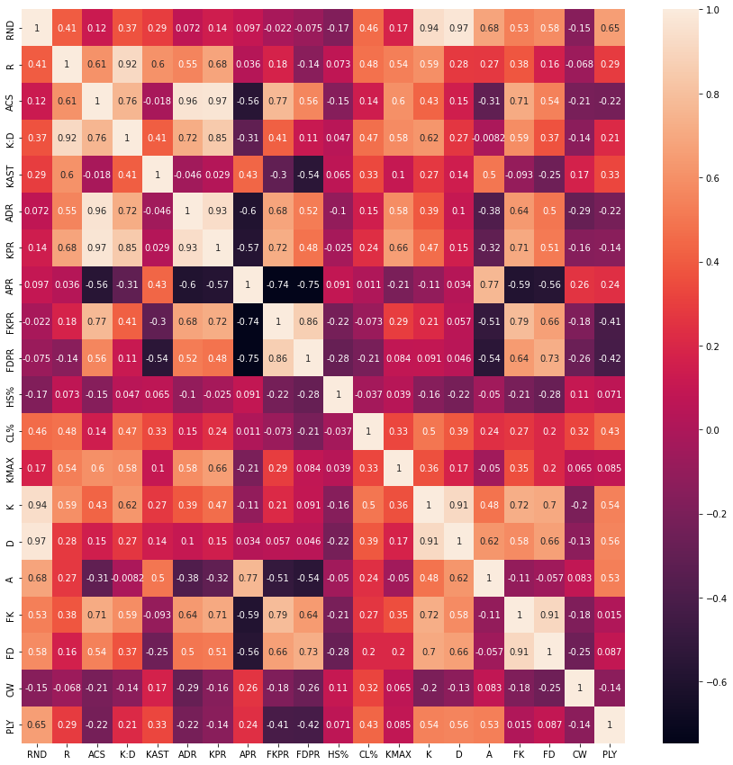

```python
plt.figure(figsize= (15,15))
sns.heatmap(vctApac.corr(), annot= True)
```

```python
# as we can see there is a many columns that has correlation with another columns
# we can tell the strong correlation is above 0.5
# next our task will be explore some insight from this data
```

```python
# first we want to know which player have highest score of ACS (Average Combat Score) in game
# ACS is the variable to see how your involment in the game
# ACS was masured from your kills & death ratio, total damage, assist, multikills, non-damagin assist
# usually if your ACS score is 100, this is the lowest ACS score you can get and above 400 is the most rare and insane how your involement in the game
```

```python
vctApac.sort_values('ACS', ascending= False).head(5)
```

|  | Player | Team | Agent 1 | Agent 2 | Agent 2.1 | RND | R | ACS | K:D | KAST | ADR | KPR | APR | FKPR | FDPR | HS% | CL% | KMAX | K | D | A | FK | FD | CW | PLY |
| --- | --- | --- | --- | --- | --- | --- | --- | --- | --- | --- | --- | --- | --- | --- | --- | --- | --- | --- | --- | --- | --- | --- | --- | --- | --- |
| 6 | Sayaplayer | T1 | NaN | NaN | NaN | 638 | 1.13 | 241.0 | 1.28 | 0.72 | 158.5 | 0.86 | 0.15 | 0.19 | 0.16 | 0.26 | 0.18 | 27 | 550 | 431 | 98 | 124 | 105 | 1 | 60 |
| 4 | f0rsakeN | PRX | yoru | neon | jett | 522 | 1.14 | 233.4 | 1.19 | 0.76 | 149.5 | 0.82 | 0.30 | 0.16 | 0.09 | 0.27 | 0.15 | 26 | 426 | 357 | 156 | 85 | 49 | 4 | 24 |
| 9 | Suggest | DFM | jett | raze | killjoy | 253 | 1.08 | 232.5 | 1.09 | 0.74 | 155.2 | 0.80 | 0.20 | 0.12 | 0.10 | 0.29 | 0.07 | 29 | 202 | 185 | 51 | 30 | 25 | 2 | 24 |
| 3 | Monyet | GE | omen | astra | viper | 361 | 1.16 | 231.8 | 1.18 | 0.75 | 148.7 | 0.83 | 0.42 | 0.11 | 0.09 | 0.28 | 0.21 | 39 | 299 | 253 | 151 | 41 | 33 | 8 | 38 |
| 27 | Seoldam | DFM | NaN | NaN | NaN | 231 | 0.97 | 228.2 | 0.95 | 0.67 | 137.3 | 0.76 | 0.17 | 0.24 | 0.21 | 0.16 | 0.00 | 23 | 176 | 185 | 39 | 55 | 49 | 0 | 18 |

```python
# we can see the top 5 with the highest ACS
# now we need to see the correlation ACS with another columns
# if we see ACS have a strong correlation with KPR/Kills Per Round
# now we see wich player have the highest with these two variable
```

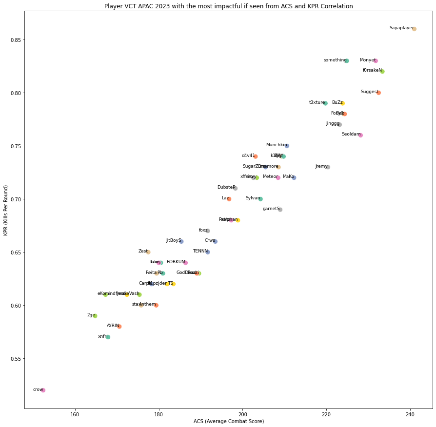

```python
plt.figure(figsize= (15,15)) # view size configuration

## Visualization ##

### parameters decription ###
# x for data in X axis and y for Y axis
# hue to control the colour based on data we want to highlight
# legend to give you information colour from hue value
# s for the size of the dot
# data for the input data we want to get
sns.scatterplot(x= 'ACS', y= 'KPR', hue= 'Player', palette= 'Set2', s= 100, legend= False, data= vctApac)

for i in range(len(vctApac)):
    plt.text(vctApac['ACS'][i], vctApac['KPR'][i], vctApac['Player'][i], fontsize=9, ha='right')

plt.xlabel('ACS (Average Combat Score)')
plt.ylabel('KPR (Kills Per Round)')
plt.title('Player VCT APAC 2023 with the most impactful if seen from ACS and KPR Correlation')
plt.show()
```

### ACS-KPR Insight

the top 5 player who have the highest ACS

1. Sayaplayer
2. f0rsaken
3. Suggest
4. Monyet
5. Soeldam

**Sayaplayer became the most impactful player in terms of ACS and KPR in the game with T1 among other players in the VCT APAC 2023 league**

```python
# if we see after KPR ACS have strong correlation with ADR/Average Damage Per Round
# ADR also represent on how impactful you at the game
# but strongly reminder ADR/Average Damage per Round is calculated from your damage shoot and skills agent and and depending on what agent you're up against
# thats why ADR is not a good statistic to see your contribution in game
# but we still look at it
```

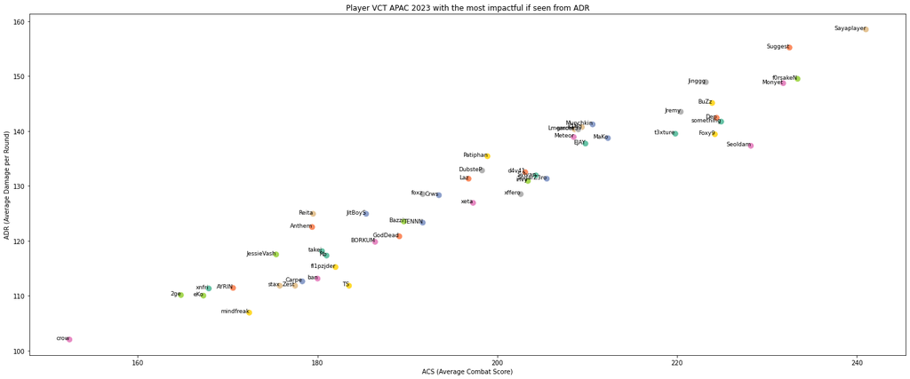

```python
plt.figure(figsize= (25,10)) # view size configuration

## Visualization ##

### parameters decription ###
# x for data in X axis and y for Y axis
# hue to control the colour based on data we want to highlight
# legend to give you information colour from hue value
# s for the size of the dot
# data for the input data we want to get
sns.scatterplot(x= 'ACS', y= 'ADR', hue= 'Player', palette= 'Set2', s= 100, legend= False, data= vctApac)

for i in range(len(vctApac)):
    plt.text(vctApac['ACS'][i], vctApac['ADR'][i], vctApac['Player'][i], fontsize=9, ha='right')

plt.xlabel('ACS (Average Combat Score)')
plt.ylabel('ADR (Average Damage per Round)')
plt.title('Player VCT APAC 2023 with the most impactful if seen from ADR')
plt.show()
```

```python
vctApac[['Player', 'Agent 1', 'Agent 2', 'Agent 2.1','ACS', 'ADR']].sort_values('ADR', ascending= False).head(5)
```

|  | Player | Agent 1 | Agent 2 | Agent 2.1 | ACS | ADR |
| --- | --- | --- | --- | --- | --- | --- |
| 6 | Sayaplayer | NaN | NaN | NaN | 241.0 | 158.5 |
| 9 | Suggest | jett | raze | killjoy | 232.5 | 155.2 |
| 4 | f0rsakeN | yoru | neon | jett | 233.4 | 149.5 |
| 7 | Jinggg | raze | phoenix | sage | 223.2 | 148.9 |
| 3 | Monyet | omen | astra | viper | 231.8 | 148.7 |

### ADR-ACS-Agent Insight

We can see the top of the board still **Sayaplayer** with the most **impactful** player for the team, but we also know the ACS dan ADR from most of the agent played are *Duelist*, according from the role agent in valorant *Duelist* known as the agent who can penatrate or brake the defence of the opponent with the ability to move and kill fast

Except Monyet not using *Duelist*, although sometimes monyet played as a *Duelist*.

[figure not shown]

```python
plt.figure(figsize= (25,10)) # view size configuration

## Visualization ##

### parameters decription ###
# x for data in X axis and y for Y axis
# hue to control the colour based on data we want to highlight
# legend to give you information colour from hue value
# s for the size of the dot
# data for the input data we want to get
sns.scatterplot(x= 'ADR', y= 'KPR', hue= 'Player', palette= 'Set2', s= 100, legend= False, data= vctApac)

for i in range(len(vctApac)):
    plt.text(vctApac['ADR'][i], vctApac['KPR'][i], vctApac['Player'][i], fontsize=9, ha='right')

plt.xlabel('ADR (Average Damage per Round)')
plt.ylabel('KPR (Kills per Round)')
plt.title('The Correlation KPR-ADR Player in VCT APAC 2023')
plt.show()
```

### KPR-ADR Insight

KPR also have strong correlation with ADR. but this is not difference from other figure that have a correlation with KPR. this statistic show KPR also have the impact with ADR score you got.

```python
# after seeing KDA insight there is called KAST. KAST is how the player can get a kills and assist then survie to trade a kills in game
# this variable important to see how well the player can play and trade with the natural skills of kills and assist in the game

vctApac[['Player', 'KAST', 'A', 'RND']].sort_values('KAST',ascending= False).head(5)
```

|  | Player | KAST | A | RND |
| --- | --- | --- | --- | --- |
| 1 | d4v41 | 0.80 | 216 | 522 |
| 0 | something | 0.78 | 97 | 432 |
| 8 | Sylvan | 0.77 | 76 | 204 |
| 2 | MaKo | 0.77 | 304 | 637 |
| 11 | xeta | 0.77 | 234 | 638 |

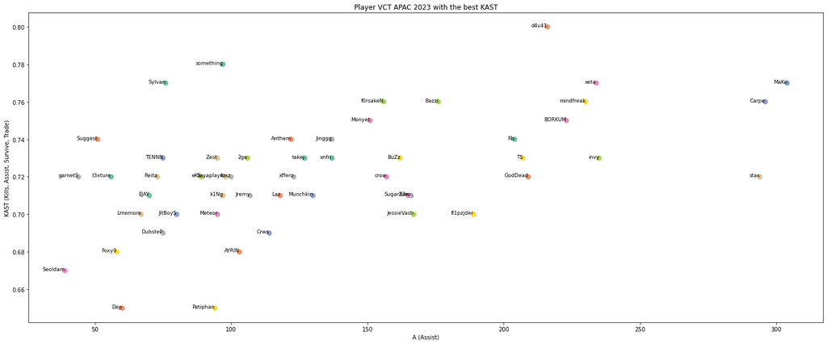

```python
plt.figure(figsize= (25,10)) # view size configuration

## Visualization ##

### parameters decription ###
# x for data in X axis and y for Y axis
# hue to control the colour based on data we want to highlight
# legend to give you information colour from hue value
# s for the size of the dot
# data for the input data we want to get
sns.scatterplot(x= 'A', y= 'KAST', hue= 'Player', palette= 'Set2', s= 100, legend= False, data= vctApac)

for i in range(len(vctApac)):
    plt.text(vctApac['A'][i], vctApac['KAST'][i], vctApac['Player'][i], fontsize=9, ha='right')

plt.xlabel('A (Assist)')
plt.ylabel('KAST (Kills, Assist, Survive, Trade)')
plt.title('Player VCT APAC 2023 with the best KAST')
plt.show()
```

### KAST-A Insight

**KAST** is stands for **Kills, Assist, Survive, Trade**. This meaning the player who got kills, helping their teammate, survive until the end of the game, and being traded by a teammate within a short time after dying.

In short KAST is the player who can get succesfully survive and kills to help their teammate.

In that scatterplot we can see **d4v41** got the highest KAST percentage.

According to https://gametree.me/gaming-terms/valorant/kast/ KAST is calculated by **KAST % = (Rounds with a Kill, Assist, Survival, or Trade / Total Rounds Played) x 100**

```python
top_5_APR = vctApac[['Player', 'Agent 1', 'Agent 2', 'Agent 2.1', 'APR', 'A']].sort_values('APR', ascending=False).head(5)
top_5_APR
```

|  | Player | Agent 1 | Agent 2 | Agent 2.1 | APR | A |
| --- | --- | --- | --- | --- | --- | --- |
| 12 | invy | kayo | breach | skye | 0.50 | 235 |
| 20 | Bazzi | skye | fade | sova | 0.49 | 176 |
| 2 | MaKo | omen | viper | brimstone | 0.48 | 304 |
| 29 | fl1pzjder | breach | kayo | skye | 0.48 | 189 |
| 48 | xnfri | harbor | omen | brimstone | 0.47 | 137 |

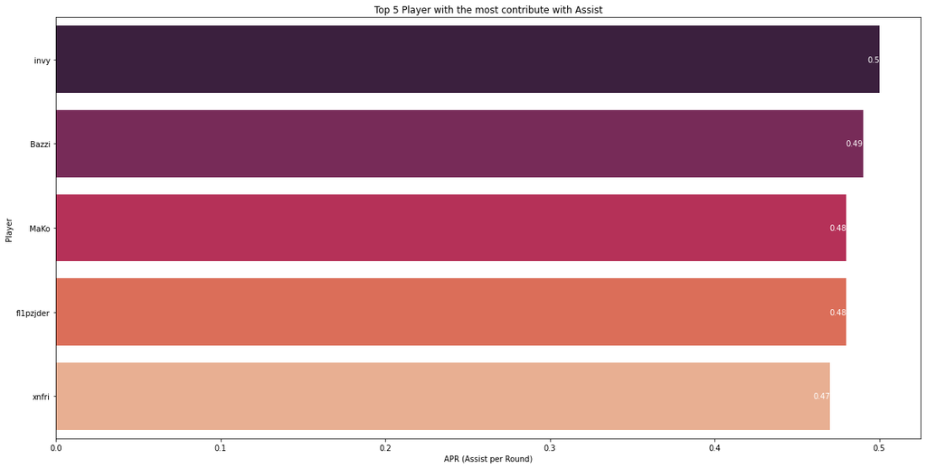

```python
plt.figure(figsize=(20,10)) # view size configuration

# make a barplot
sns.barplot(x=top_5_APR['APR'], y=top_5_APR['Player'], palette='rocket')

# to make a label in the barplot
for index, value in enumerate(top_5_APR['APR']):
    plt.text(value, index, f'{value}', color='white', ha='right', va='center')

plt.title('Top 5 Player with the most contribute with Assist')
plt.xlabel('APR (Assist per Round)')
plt.ylabel('Player')
plt.show()
```

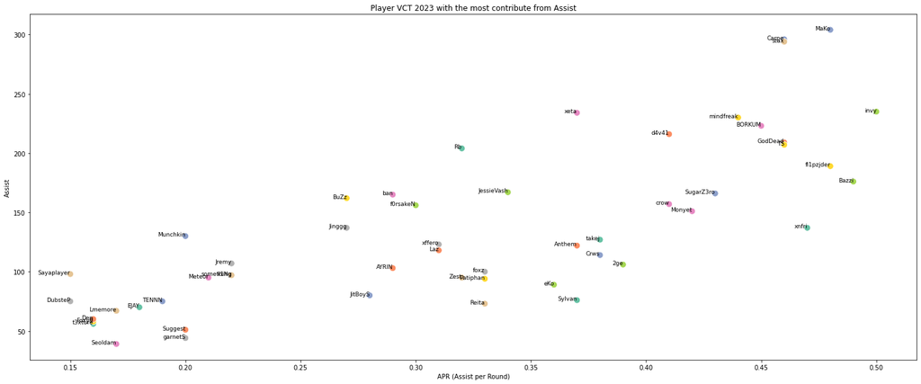

```python
plt.figure(figsize= (25,10)) # view size configuration

## Visualization ##

### parameters decription ###
# x for data in X axis and y for Y axis
# hue to control the colour based on data we want to highlight
# legend to give you information colour from hue value
# s for the size of the dot
# data for the input data we want to get
sns.scatterplot(x= 'APR', y= 'A', hue= 'Player', palette= 'Set2', s= 100, legend= False, data= vctApac)

for i in range(len(vctApac)):
    plt.text(vctApac['APR'][i], vctApac['A'][i], vctApac['Player'][i], fontsize=9, ha='right')

plt.xlabel('APR (Assist per Round)')
plt.ylabel('Assist')
plt.title('Player VCT 2023 with the most contribute from Assist')
plt.show()
```

### APR-A Insight

APR or **Assist per Round** like shown in two figure above, tell us how the player contribute with Assist. it can be see as how the player on your temmate play because it also calculated with the skills the agent been played. in this figure show the player **invy** have a highest APR.

This statistic is good to see how the player have good sense on reading the enemy to give some damage.

We can see also the player before like sayaplayer, f0rsaken, something don't have a high APR. This indicates that the player who have the most kills and ADR not contribute from Asisst because the way they played with **Duelist** Agent and mostly being palyer who penetrate alone, so it's make sense they not got the hight APR.

```python
# make a new dataframe for easier to get the data
top_5_cl = vctApac[['Player', 'Agent 1', 'Agent 2', 'Agent 2.1', 'CL%', 'K']].sort_values('CL%', ascending=False).head(5)
top_5_cl
```

|  | Player | Agent 1 | Agent 2 | Agent 2.1 | CL% | K |
| --- | --- | --- | --- | --- | --- | --- |
| 0 | something | jett | breach | reyna | 0.25 | 357 |
| 2 | MaKo | omen | viper | brimstone | 0.24 | 456 |
| 3 | Monyet | omen | astra | viper | 0.21 | 299 |
| 16 | t3xture | jett | raze | sage | 0.21 | 268 |
| 24 | Rb | killjoy | harbor | astra | 0.20 | 400 |

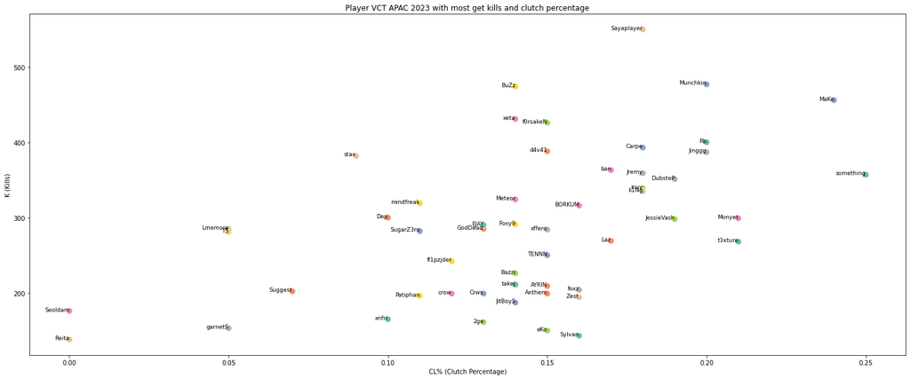

```python
plt.figure(figsize= (25,10)) # view size configuration

## Visualization ##

### parameters decription ###
# x for data in X axis and y for Y axis
# hue to control the colour based on data we want to highlight
# legend to give you information colour from hue value
# s for the size of the dot
# data for the input data we want to get
sns.scatterplot(x= 'CL%', y= 'K', hue= 'Player', palette= 'Set2', s= 100, legend= False, data= vctApac)

for i in range(len(vctApac)):
    plt.text(vctApac['CL%'][i], vctApac['K'][i], vctApac['Player'][i], fontsize=9, ha='right')

plt.xlabel('CL% (Clutch Percentage)')
plt.ylabel('K (Kills)')
plt.title('Player VCT APAC 2023 with most get kills and clutch percentage')
plt.show()
```

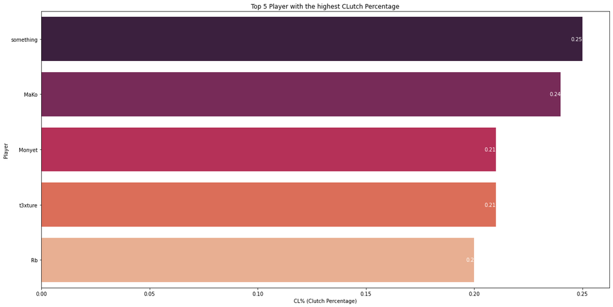

```python
plt.figure(figsize=(20,10)) # view size configuration

# make a barplot
sns.barplot(x=top_5_cl['CL%'], y=top_5_cl['Player'], palette='rocket')

# to make a label in the barplot
for index, value in enumerate(top_5_cl['CL%']):
    plt.text(value, index, f'{value}', color='white', ha='right', va='center')

plt.title('Top 5 Player with the highest CLutch Percentage')
plt.xlabel('CL% (Clutch Percentage)')
plt.ylabel('Player')
plt.show()
```

### CL% Insight

Clutch (CL) is the player who can win a round when being a last man standing. Clutch also have a strong correlation with kills (K). but even the player have the most kills it dosen't mean the player got the win clutch in a round.

As we can see **something** is the most player who have the highest **Clutch Percentage**. This meaning that the player have most won a round they played when this player being the last man standing. This statistics is depens on your round you played and how much you can win.

### Team Statistics

```python
# next we want to know the over all performance from the team that played in VCT APAC 2023
# but first we have to see the paricipate team
print('Total Team :', vctApac['Team'].nunique())
print('List Team :', vctApac['Team'].unique())
```

```
Total Team : 10
List Team : ['PRX' 'DRX' 'GE' 'T1' 'GEN' 'DFM' 'TS' 'RRQ' 'ZETA' 'TLN']
```

```python
print('Total Roaster per Team')
vctApac['Team'].value_counts()
```

```
Total Roaster per Team
```

```
DRX     6
GEN     6
DFM     6
PRX     5
T1      5
TS      5
RRQ     5
ZETA    5
TLN     5
GE      4
Name: Team, dtype: int64
```

```python
# we just choosing the column that we need to see the performance of the team
performanceParam = vctApac[['Team', 'ACS', 'KPR', 'ADR', 'KAST', 'HS%','CL%']]
```

```python
# make a new initiation to make avarage calculation by team
avg_team = performanceParam.groupby('Team', as_index = False).mean().round(2) # roun(2) to minimalise the float to two behind the coma
avg_team
```

|  | Team | ACS | KPR | ADR | KAST | HS% | CL% |
| --- | --- | --- | --- | --- | --- | --- | --- |
| 0 | DFM | 194.67 | 0.67 | 128.22 | 0.72 | 0.26 | 0.08 |
| 1 | DRX | 199.12 | 0.70 | 127.35 | 0.73 | 0.27 | 0.16 |
| 2 | GE | 202.95 | 0.71 | 130.78 | 0.73 | 0.24 | 0.18 |
| 3 | GEN | 193.68 | 0.67 | 125.68 | 0.72 | 0.23 | 0.14 |
| 4 | PRX | 211.40 | 0.75 | 135.90 | 0.77 | 0.24 | 0.17 |
| 5 | RRQ | 193.56 | 0.68 | 126.36 | 0.71 | 0.26 | 0.12 |
| 6 | T1 | 201.44 | 0.71 | 130.46 | 0.73 | 0.23 | 0.17 |
| 7 | TLN | 195.70 | 0.67 | 131.48 | 0.70 | 0.25 | 0.12 |
| 8 | TS | 196.78 | 0.68 | 128.90 | 0.72 | 0.23 | 0.18 |
| 9 | ZETA | 194.16 | 0.68 | 126.06 | 0.70 | 0.23 | 0.13 |

```python
# making a new variable to sorting the ACS
acs_avg_srtd = avg_team[['Team', 'ACS']].sort_values(by= 'ACS', ascending= False)
acs_avg_srtd
```

|  | Team | ACS |
| --- | --- | --- |
| 4 | PRX | 211.40 |
| 2 | GE | 202.95 |
| 6 | T1 | 201.44 |
| 1 | DRX | 199.12 |
| 8 | TS | 196.78 |
| 7 | TLN | 195.70 |
| 0 | DFM | 194.67 |
| 9 | ZETA | 194.16 |
| 3 | GEN | 193.68 |
| 5 | RRQ | 193.56 |

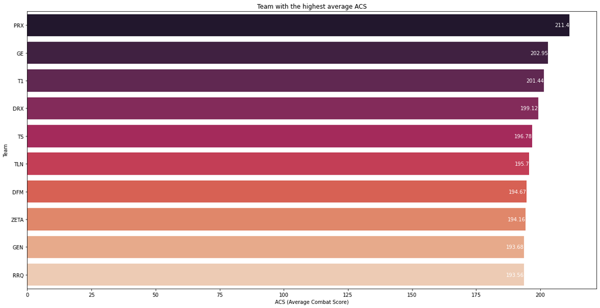

```python
plt.figure(figsize=(20,10)) # view size configuration

# make a barplot
sns.barplot(x=acs_avg_srtd['ACS'], y=acs_avg_srtd['Team'], palette='rocket')

# to make a label in the barplot
for index, value in enumerate(acs_avg_srtd['ACS']):
    plt.text(value, index, f'{value}', color='white', ha='right', va='center')

plt.title('Team with the highest average ACS')
plt.xlabel('ACS (Average Combat Score)')
plt.ylabel('Team')
plt.show()
```

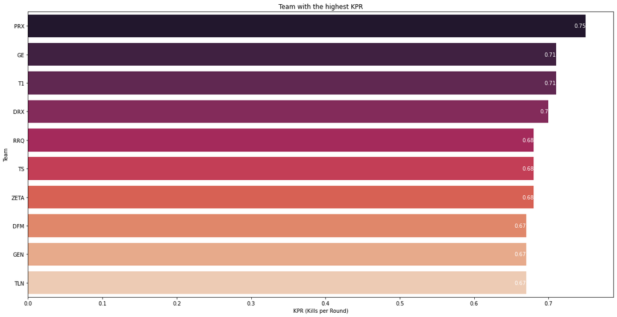

```python
# making a new variable to sorting the KPR
kpr_avg_team = avg_team[['Team', 'KPR']].sort_values(by= 'KPR', ascending= False)

plt.figure(figsize=(20,10)) # view size configuration

# make a barplot
sns.barplot(x=kpr_avg_team['KPR'], y=kpr_avg_team['Team'], palette='rocket')


# to make a label in the barplot
for index, value in enumerate(kpr_avg_team['KPR']):
    plt.text(value, index, f'{value}', color='white', ha='right', va='center')

plt.title('Team with the highest KPR')
plt.xlabel('KPR (Kills per Round)')
plt.ylabel('Team')
plt.show()
```

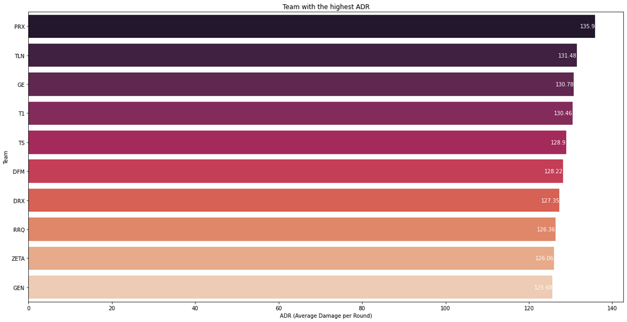

```python
# making a new variable to sorting the ADR
adr_avg_team = avg_team[['Team', 'ADR']].sort_values(by= 'ADR', ascending= False)

plt.figure(figsize=(20,10)) # view size configuration

# make a barplot
sns.barplot(x=adr_avg_team['ADR'], y=adr_avg_team['Team'], palette='rocket')


# to make a label in the barplot
for index, value in enumerate(adr_avg_team['ADR']):
    plt.text(value, index, f'{value}', color='white', ha='right', va='center')

plt.title('Team with the highest ADR')
plt.xlabel('ADR (Average Damage per Round)')
plt.ylabel('Team')
plt.show()
```

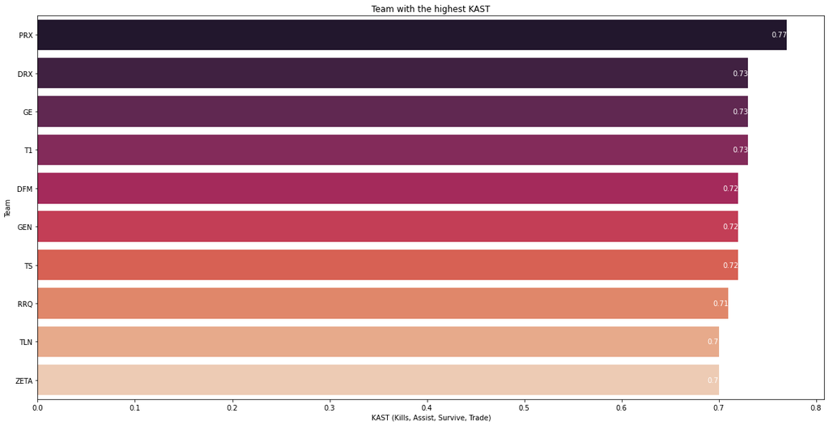

```python
# making a new variable to sorting the KAST
kast_avg_team = avg_team[['Team', 'KAST']].sort_values(by= 'KAST', ascending= False)

plt.figure(figsize=(20,10)) # view size configuration

# make a barplot
sns.barplot(x=kast_avg_team['KAST'], y=kast_avg_team['Team'], palette='rocket')


# to make a label in the barplot
for index, value in enumerate(kast_avg_team['KAST']):
    plt.text(value, index, f'{value}', color='white', ha='right', va='center')

plt.title('Team with the highest KAST')
plt.xlabel('KAST (Kills, Assist, Survive, Trade)')
plt.ylabel('Team')
plt.show()
```

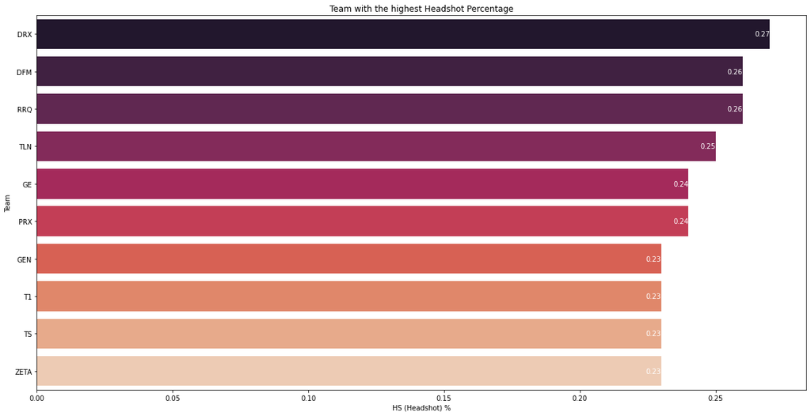

```python
# making a new variable to sorting the HS%
hs_avg_team = avg_team[['Team', 'HS%']].sort_values(by= 'HS%', ascending= False)

plt.figure(figsize=(20,10)) # view size configuration

# make a barplot
sns.barplot(x=hs_avg_team['HS%'], y=hs_avg_team['Team'], palette='rocket')


# to make a label in the barplot
for index, value in enumerate(hs_avg_team['HS%']):
    plt.text(value, index, f'{value}', color='white', ha='right', va='center')

plt.title('Team with the highest Headshot Percentage')
plt.xlabel('HS (Headshot) %')
plt.ylabel('Team')
plt.show()
```

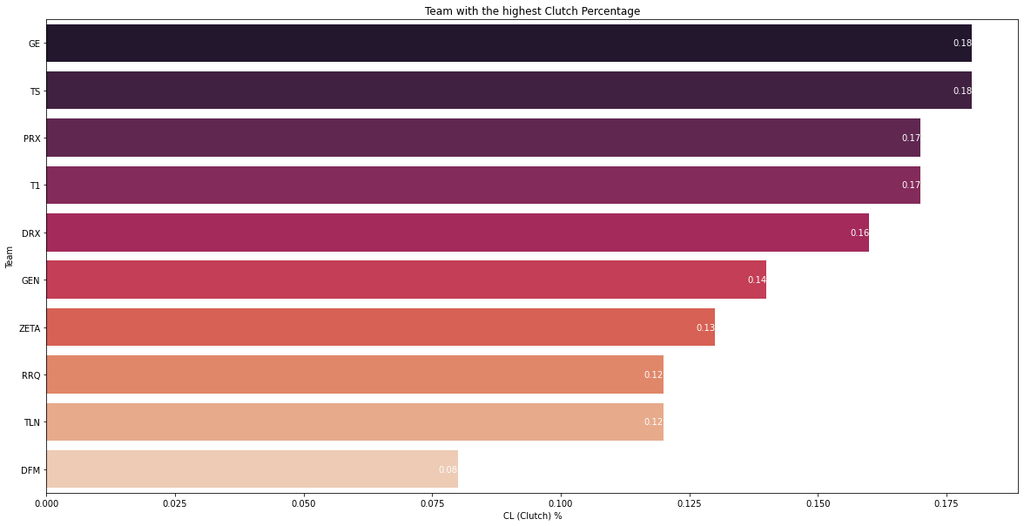

```python
# making a new variable to sorting the CL%
cl_avg_team = avg_team[['Team', 'CL%']].sort_values(by= 'CL%', ascending= False)

plt.figure(figsize=(20,10)) # view size configuration

# make a barplot
sns.barplot(x=cl_avg_team['CL%'], y=cl_avg_team['Team'], palette='rocket')


# to make a label in the barplot
for index, value in enumerate(cl_avg_team['CL%']):
    plt.text(value, index, f'{value}', color='white', ha='right', va='center')

plt.title('Team with the highest Clutch Percentage')
plt.xlabel('CL (Clutch) %')
plt.ylabel('Team')
plt.show()
```

### Team Insight

Over all **PRX** and **GE** being the team that have a good statistics among other team, this indicates how the individually player in the team have a good skills and good comps. It's not just about individual skills and agent composition, there are non-technical factors that can also affect the team's performance such as player fitness, how the coach can change the atmosphere between players, and giving instructions during time outs.